# Example analysis script for SYTO 9/PI stained yeast treated with H2O2

Hanxi Tang, Bin He

2025-06-12 (updated 2025-06-16 13:55:02.080559)

```r
require(tidyverse)
require(flowCore)
#require(flowClust)
require(openCyto)
require(ggcyto)
require(cowplot)
#require(ggrdiges)
```

```r
old <- theme_set(theme_minimal(base_size = 14) + panel_border(color = "gray20"))
```

# Background & Goal

This is an example analysis script for the flow cytometry data of *Candida glabrata* treated with hydrogen peroxide (H2O2) and stained with SYTO 9 and propidium iodide (PI). The goal is to demonstrate how to gate the flow cytometry data, extract statistics, and compare the results with colony-forming unit (CFU) counts. This script serves as a template for readers of our JOVE paper.

# Import data

The experiments for *C. glabrata* were conducted on 2024.02.14-17. Post-treatment cells were stained with PI or PI+SYTO9, and run through flow cytometry. The same sample was also plated for CFU.

*note*: samples are labeled by the H2O2 doses they were treated with. an exception is “5C”, which refers to samples taken prior to the treatment and stored in the fridge at 5 Celsius until treated samples are ready for flow cytometer. this was done as a control experiment. ask Hanxi about the specific rationale.

```r
# use relative path to make it easier for collaboration
data.path = "../input/20240214-17 Log range correlation/"
dat0 <- read.flowSet(path = data.path, pattern = "*.fcs",
                     transformation = FALSE,  # the original values are already linearized.
                     emptyValue = FALSE,  alter.names = TRUE,   # change parameter names to R format
                     column.pattern = ".H|FSC|SSC") # only load the height variables for the fluorescent parameters
```

Simplify the sample names

```r
oriNames <- sampleNames(dat0)
tmp <- str_split(oriNames, pattern = "[ _]+", simplify = TRUE)[,c(1, 6, 7)]
colnames(tmp) <- c("Date", "Treatment", "Dye")
#treatment.levels <- c("mock", "5C", "10", "100", "1000")
sample <- data.frame(tmp) %>%
  mutate(
    Dye = ifelse(Dye == "p.fcs", "PI", ifelse(Dye == "b.fcs", "Both", Dye)),
    Treatment = fct_inorder(Treatment),
    name = paste(Date, paste0(Treatment,
                              ifelse(Treatment == "5C", "", "mM")),
                 Dye, sep = "_")
  )
rownames(sample) <- oriNames
dat <- dat0 # make a copy
pData(dat) <- sample
write_tsv(pData(dat), file = "../input/20240214-log-h2o2-cg-sample.tsv")
```

# Gatting strategies

Gate specification. Note that these gates need to be adjusted for your specific instrument and data.

```r
source("../script/20250612-FGL-flow-gate-specification.R")
```

## Gating for singlets

> Gate for cell events and remove non-cell particles with a rectangular gate

[output not shown]

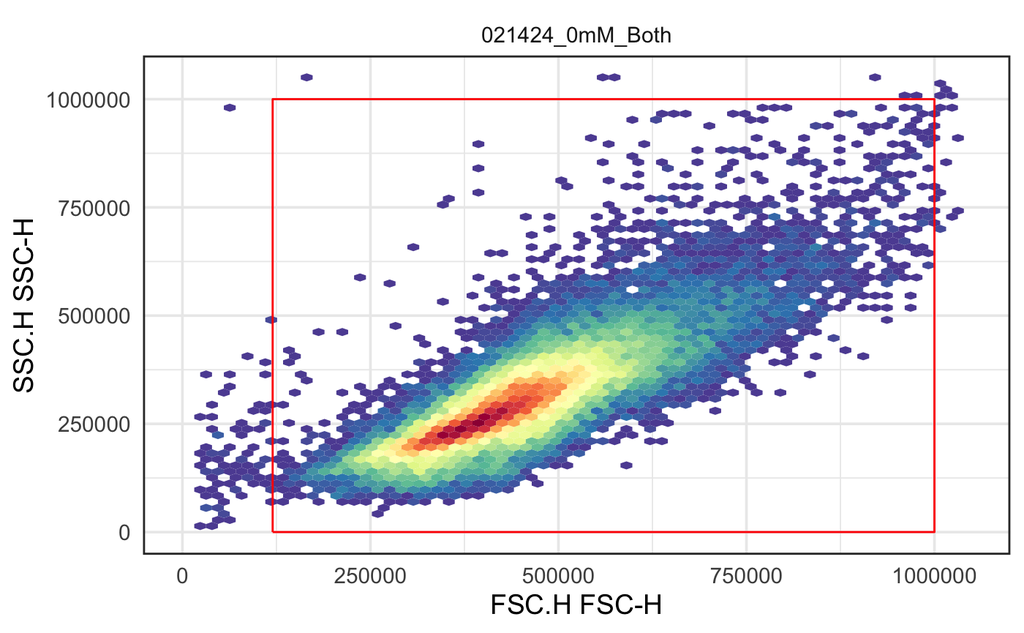

```r
ggcyto(dat[1], aes(x = FSC.H, y = SSC.H), subset = "root") +
  geom_hex(bins = 64) + geom_gate(outlier.gate) + facet_wrap(~name, ncol = 2) + ggcyto_par_set(limits = "instrument")
```

Add gate to GS

```r
gs <- GatingSet(dat) # create a GatingSet
# rename the samples
sampleNames(gs) <- pData(gs)$name
# repair the Date column in pData
pData(gs)$Date = paste0("0", pData(gs)$Date)
# add the outlier gate
gs_pop_add(gs, outlier.gate, parent = "root")
```

```
[1] 2
```

```r
recompute(gs)
```

```
done!
```

> Gate for singlets

[output not shown]

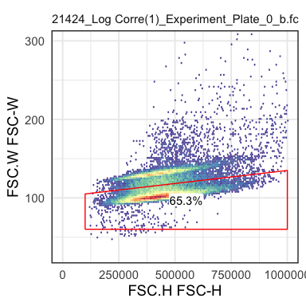

```r
scPars <- ggcyto_par_set(limits = list(x = c(0,1e6), y = c(30,300)))
ex <- Subset(dat[[1]], outlier.gate)
ggcyto(ex, aes(x = FSC.H, y = FSC.W)) + geom_hex(bins = 128) + geom_gate(singlet.gate) + geom_stats() + scPars
```

Add this gate to the gatingSet

```r
gs_pop_add(gs, singlet.gate, parent = "-outlier", name = "singlet")
```

```
[1] 3
```

```r
recompute(gs)
```

```
done!
```

## Gate for live cells

> Gate for live cells with red fluorescence below 10^2.2

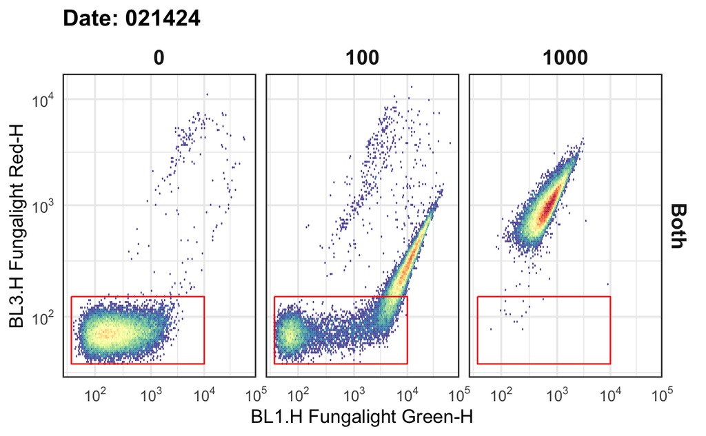

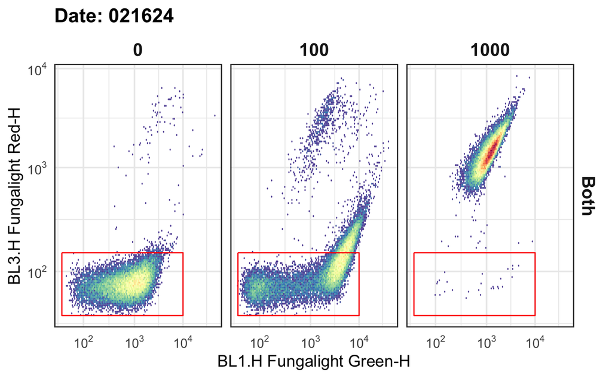

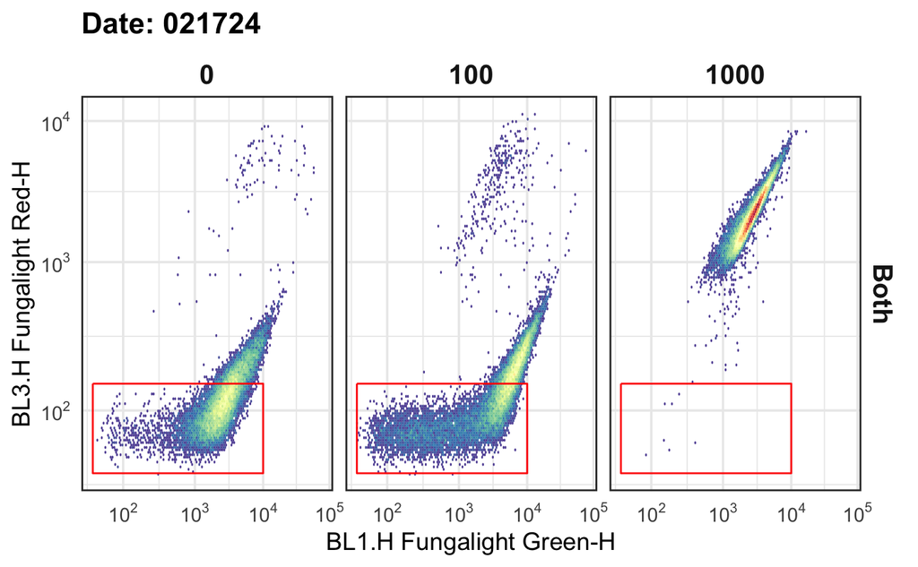

```r
scPars <- ggcyto_par_set(limits = list(x = c(0,10^5.5), y = c(0,10^5.5)))
#polygon <- matrix(c(0, 5*10^3, 5*10^3, 0, # BL1.H, green
#                    10^2.2, 10^2.2, 0, 0),# BL3.H, red
#                  ncol = 2)
#colnames(polygon) <- c("BL1.H", "BL3.H")
#live.gate <- polygonGate(filterId = "live", .gate = polygon)
p.axis <- list(
  scale_x_logicle(breaks = 10^c(2,3,4,5)),
  scale_y_logicle(breaks = 10^c(2,3,4,5)),
  theme(
    strip.text = element_text(size = rel(1.1), face = 2)
  )
)
for(date in c("021424", "021624", "021724")){
  p <- ggcyto(gs[pData(gs)$Date == date], aes(x = BL1.H, y = BL3.H), subset = "singlet") +
    geom_hex(bins = 128) +
    geom_gate(live.gate) +
    geom_stats(location = "data", adjust = c(0.005, 5), digits = 1) +
    labs(title = paste0("Date: ", date)) +
    facet_grid(Dye ~ Treatment) +# scPars +
    p.axis
  print(p)
}
```

Add this gate to the gatingSet

```r
gs_pop_add(gs, live.gate, parent = "singlet", name = "live")
```

```
[1] 4
```

```r
recompute(gs)
```

```
done!
```

## Gate for the intermediate population with high SYTO9

> Gate for the “intermediate”, oxidatively-damaged cell population with high Red and Green fluorescence. We hypothesize that they represent oxidatively damaged cells with partially compromised plasma membranes, resulting in more SYTO9 accumulation but not a significant increase in PI.

[output not shown]

[figure not shown]

[figure not shown]

[figure not shown]

```r
for(date in c("021424", "021624", "021724")){
  p <- ggcyto(gs[pData(gs)$Date == date], aes(x = BL1.H, y = BL3.H),
              subset = "singlet") +
    geom_hex(bins = 128) +
    geom_gate(inter.gate) +
    geom_stats(location = "data",  adjust = c(0.05, 5), digits = 3) +
    labs(title = paste0("Date: ", date)) +
    facet_grid(Dye ~ Treatment) + scPars +
    p.axis
  print(p)
}
```

```r
gs_pop_add(gs, inter.gate, parent = "singlet", name = "intermediate")
```

```
[1] 5
```

```r
recompute(gs)
```

```
done!
```

# Extract gated stats and MFI

% of events in each of the three gates

```r
# we are only interested in the populations after singlet gating
nodes <- c("singlet", "intermediate", "live")
# get the event count
gated_cnt <- gs_pop_get_stats(gs, nodes, type = "count")
# get the MFI for each parameter in each population of interest
gated_mfi <- gs_pop_get_stats(gs, nodes, type = pop.MFI) %>%
  select(sample, pop, starts_with("FungaLight"))
```

Combine the data and meta data

```r
gated_stats <- full_join(gated_cnt, gated_mfi, by = c("sample", "pop")) %>%
  right_join(pData(gs), by = c("sample" = "name")) %>%
  relocate(Date, Treatment, Dye, .after = sample) %>%
  relocate(sample, .after = last_col())
write_tsv(gated_stats, file = "../output/20240214-17-log-h2o2-Cg-gated-stats.tsv")

# we don't need the MFI for the latter analysis. add meta data to gated_cnt
gated_freq <- left_join(sample, gated_cnt, by = c("name" = "sample")) %>%
  select(-name) %>%
  group_by(Date, Treatment, Dye) %>%
  mutate(perc = count / count[pop == "singlet"], .after = count)
```

# Compare with CFU

Read in the raw CFU data

```r
cfu_raw <- read_tsv("../input/20240214-17-h2o2-Cg-CFU-raw.tsv",
                    col_types = "cccccciiii", comment = "#")
cfu_calc <- cfu_raw %>%
  select(Date, Treatment = H2O2_mM, Group, Dilution, Raw_count = Total) %>%
  mutate(Date = ymd(Date),
         Treatment = fct_inseq(Treatment),
         CFU = Dilution * Raw_count) %>%
  # group by Date to calculate the ratio of MO to MM
  group_by(Date) %>%
  mutate(p_live = CFU / CFU[Group == "MM"], Method = "CFU") %>%
  select(-Group) %>%
  # we only need the log dilution series
  dplyr::filter(Date < ymd("20240301"))

# export the data for paper
write_tsv(cfu_calc, file = "../output/20250612-log-h2o2-cfu-estimate.tsv")
```

## Calculate survival from PI alone or FungaLight

We will calculate the percent live events and the percent intermediate events.

```r
dye_based <- gated_freq %>%
  # record the total number of events as the count of singlets
  group_by(Date, Treatment, Dye) %>%
  mutate(total_event_count = count[pop == "singlet"]) %>%
  # now we don't need the singlet population and the count variable
  select(-count) %>%
  dplyr::filter(pop != "singlet") %>%
  # we will pivot this data frame to a wider format, making
  # two new variables out of the percentage variable
  pivot_wider(names_from = pop, values_from = perc, names_prefix = "p_") %>%
  mutate(p_dead = 1 - p_live - p_intermediate,
         Date = mdy(Date), Method = "SYTO 9/PI") %>%
  ungroup() %>%
  select(Date, Treatment, Method, total_event_count,
         p_live, p_intermediate, p_dead)

# export the data for paper
write_tsv(dye_based, file = "../output/20250612-log-h2o2-dye-estimate.tsv")
```

Combine the dye based results with CFU

```r
cfu_dye <- bind_rows(
  select(cfu_calc, Date, Treatment, Method, p_live),
  select(dye_based, Date, Treatment, Method, starts_with("p"))) %>%
  mutate(
    Method = factor(Method, levels = c("CFU", "SYTO 9/PI")),
    Treatment = fct_inorder(Treatment)
  )
```

## Plotting the results

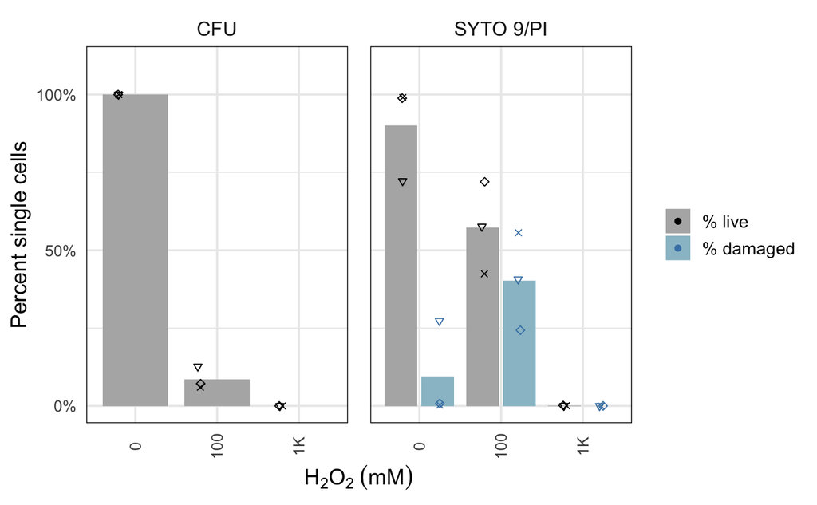

```r
h2o2.levels <- c("0" = "0", "100" = "100", "1000" = "1K")
p <- cfu_dye %>%
  select(Date, Treatment, Method, p_live, p_intermediate) %>%
  pivot_longer(cols = c(p_live, p_intermediate),
               names_to = "par", values_to = "perc") %>%
  mutate(par = factor(par, levels = c("p_live", "p_intermediate"),
                      labels = c("% live", "% damaged"))) %>%
  ggplot(aes(x = Treatment, y = perc, group = par)) +
  geom_bar(aes(fill = par), position = position_dodge(.9),
    stat = "summary", fun = "mean", width = 0.8) +
  geom_point(aes(shape = as.character(Date), color = par),
             position = position_jitterdodge(jitter.width = 0.1,
                                             dodge.width = 0.9)) +
  scale_fill_manual(NULL, values = c("gray70", "lightblue3")) +
  scale_color_manual(NULL, values = c("black", "steelblue")) +
  #ggplot(aes(x = Treatment, y = p_live, group = Method)) +
  #geom_bar(stat = "summary", fun = "mean", fill = "gray70", width = 0.7) +
  #geom_point(aes(shape = as.character(Date)), position = position_jitter(0.2),
  #           size = 1.5) +
  scale_shape_manual(values = 4:6, guide = "none") +
  scale_y_continuous(labels = scales::percent,
                     limits = c(NA, 1.1), breaks = seq(0,1,0.5)) +
  scale_x_discrete(labels = h2o2.levels) +
  #coord_flip() +
  labs(x = bquote(H[2]*O[2]~(mM)), y = "Percent single cells") +
  facet_wrap(~Method, nrow = 1) +
  theme(strip.background = element_blank(),
        strip.text = element_text(size = rel(0.9), face = 1),
        axis.text.x = element_text(size = rel(0.9), angle = 90, vjust = .5),
        axis.text.y = element_text(size = rel(0.9)),
        #axis.title = element_text(size = rel(0.9)),
        panel.border = element_rect(color = "gray0", linewidth = 0.5),
        legend.position = "right",
        panel.spacing = unit(1, "lines"))
p
ggsave("../output/20250613-perc-live-compare-dye-to-cfu.png",
       width = 6, height = 3)
```

## Statistical tests

CFU

```r
TukeyHSD(tmp)
```

[output not shown]

For p_live with SYTO 9/PI

```r
tmp <- aov(p_live ~ Treatment, data = dye_based)
TukeyHSD(tmp)
```

```
  Tukey multiple comparisons of means
    95% family-wise confidence level

Fit: aov(formula = p_live ~ Treatment, data = dye_based)

$Treatment
               diff        lwr         upr     p adj
100-0    -0.3268989 -0.6358992 -0.01789855 0.0402432
1000-0   -0.8994425 -1.2084428 -0.59044213 0.0002702
1000-100 -0.5725436 -0.8815439 -0.26354326 0.0030859
```

For p_intermediate with SYTO 9/PI

```r
tmp <- aov(p_intermediate ~ Treatment, data = dye_based)
TukeyHSD(tmp)
```

```
  Tukey multiple comparisons of means
    95% family-wise confidence level

Fit: aov(formula = p_intermediate ~ Treatment, data = dye_based)

$Treatment
                diff         lwr         upr     p adj
100-0     0.30736950 -0.01104722  0.62578623 0.0570353
1000-0   -0.09458004 -0.41299677  0.22383669 0.6535180
1000-100 -0.40194954 -0.72036627 -0.08353282 0.0192967
```